# HW2

Sarper Karabağ

# Q1

When we use distance information of Turkey’s cities to create 2D plot with MDS, we can observe that the plot looks like Turkey Map on the plot.

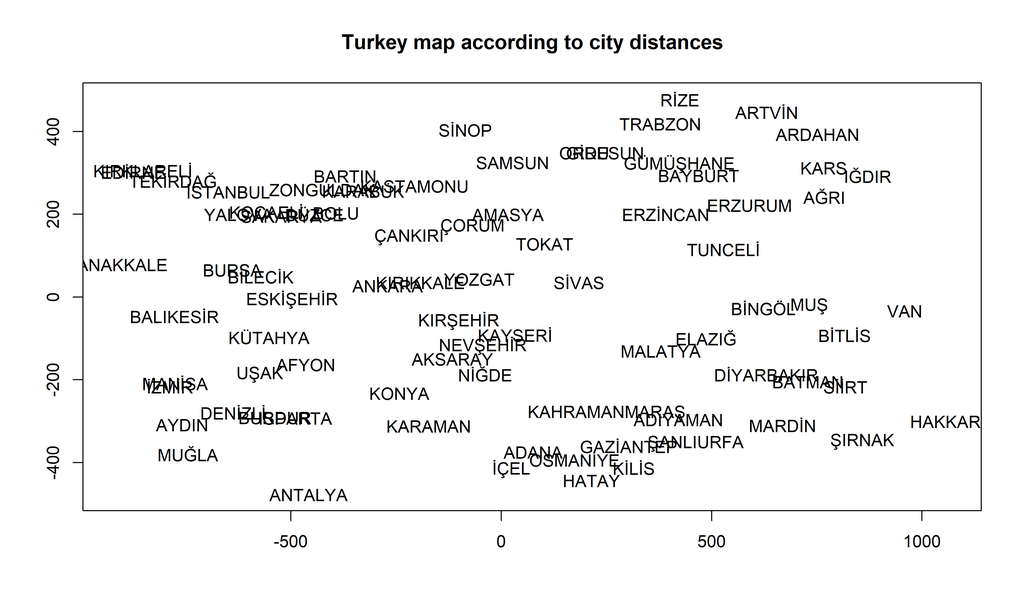

# Q2

In this question, we used Netflix data from 10000 users to create a plot, using MDS with Manhattan method. When we look at the plot, we can observe that the movies that are related or sequence are closer points to each other.

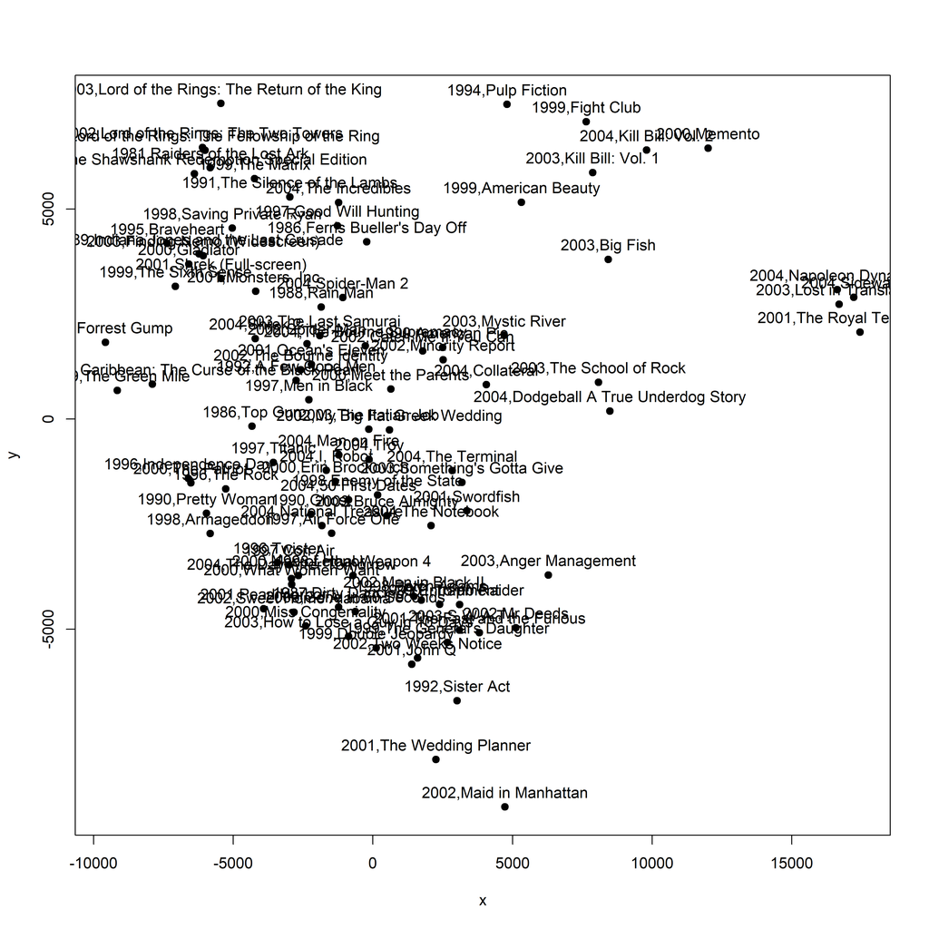

# Q3.a

In part 3, we used the data from Liu et al., which contains gesture data divided into 3 seperate files. The files are divided according to the axis information of the movement which are X,Y and Z axes. There are 8 classes in the data which shows that there 8 different people who performed gestures and we visualized every gesture movement in part a.

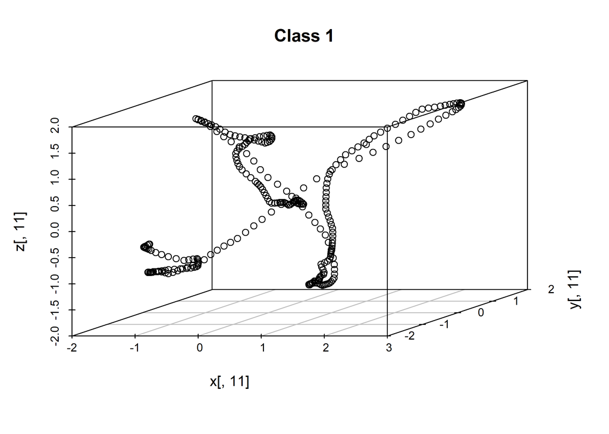

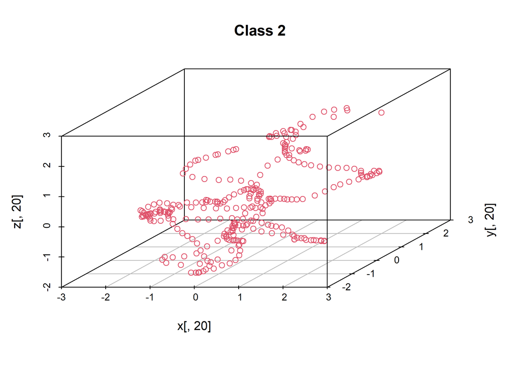

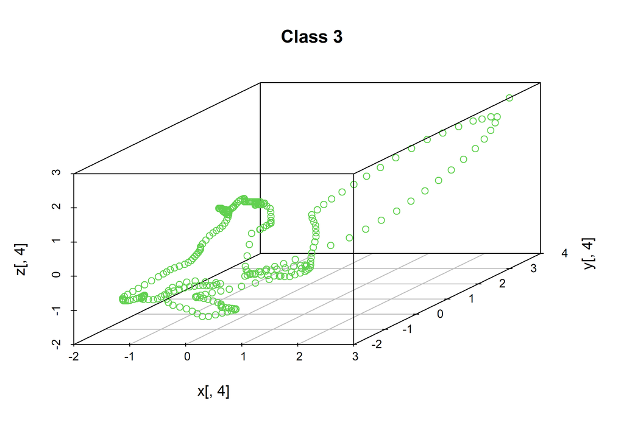

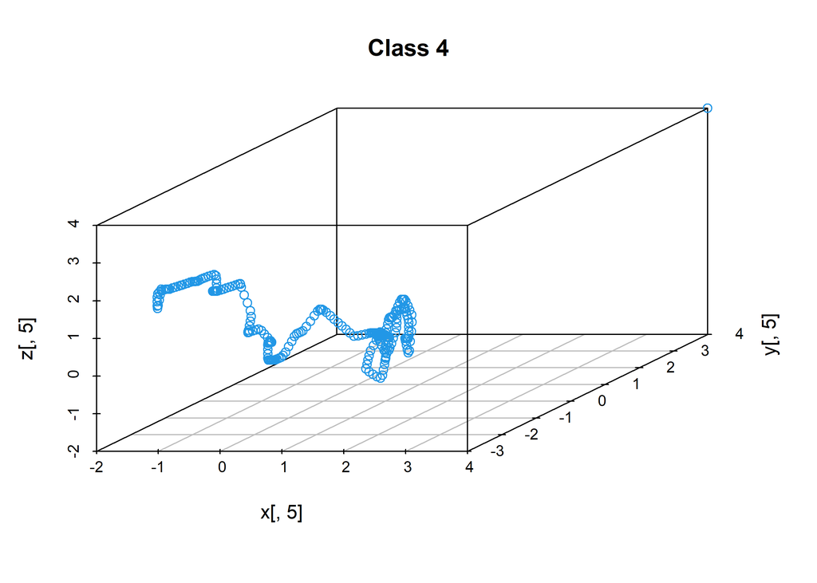

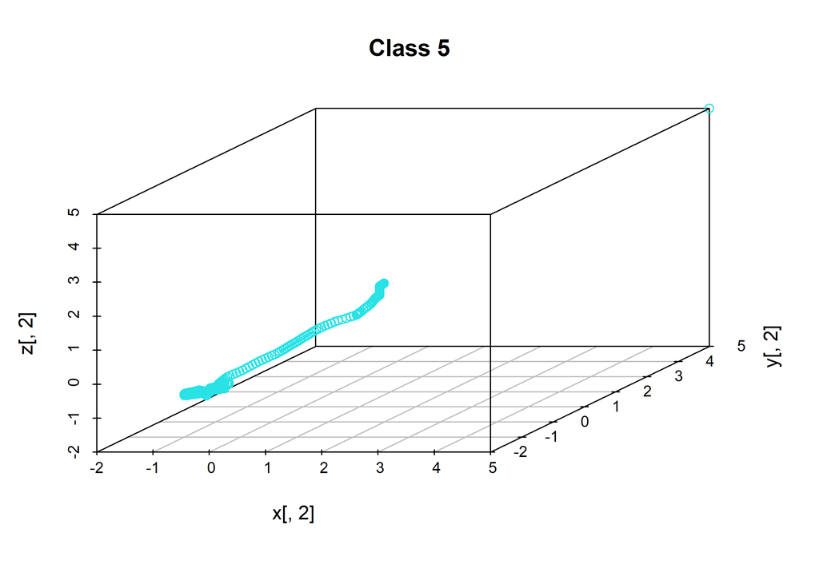

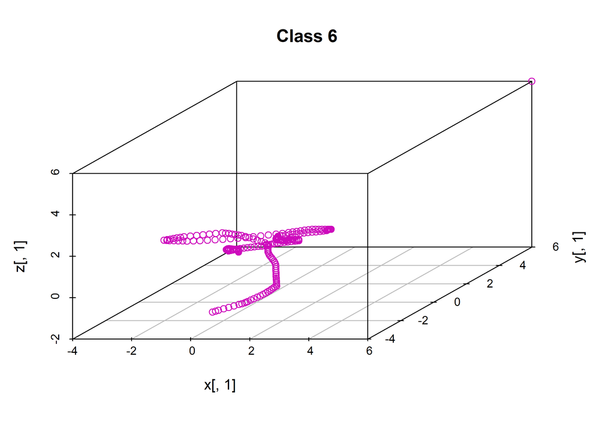

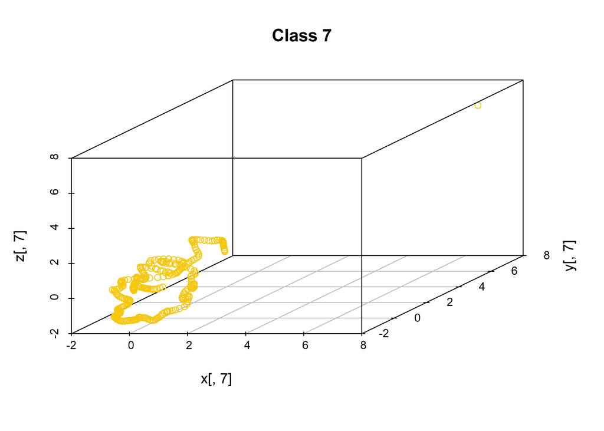

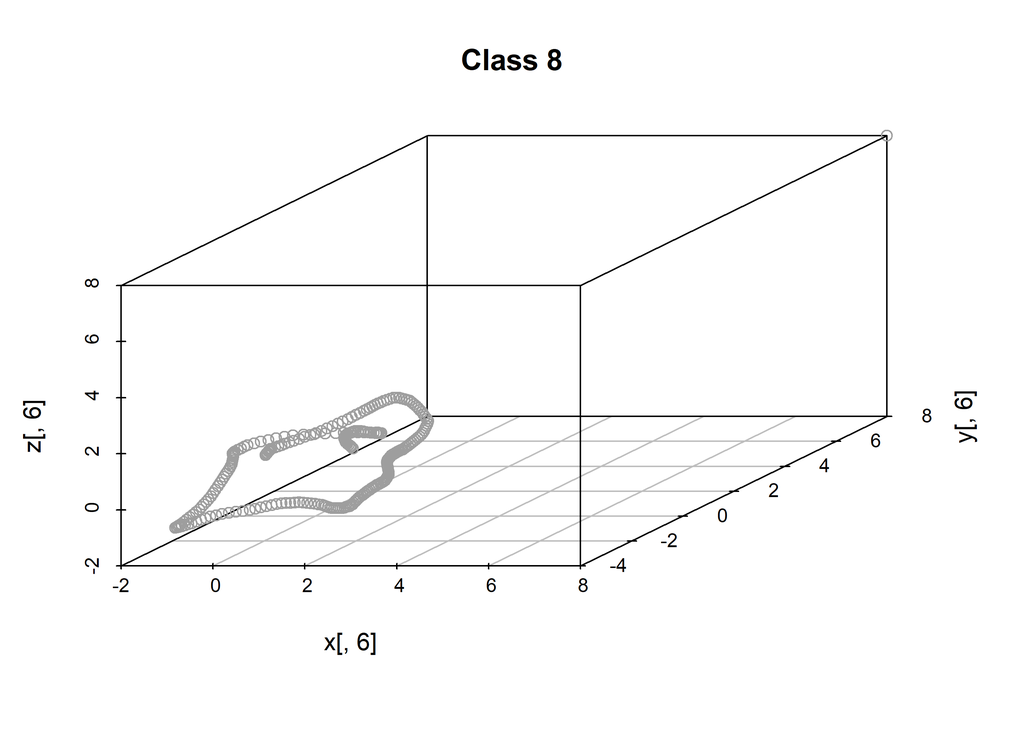

# Q3.b

In part b, we concatenate the time series of X,Y and Z axis column wise. Which can be interpreted as a row contains class(person) id, X , Y and Z data. An example tribble:

```
## # A tibble: 2,520 x 4
##       id      X     Y      Z
##    <dbl>  <dbl> <dbl>  <dbl>
##  1     1 -0.791 -1.96 -0.249
##  2     1 -0.791 -1.96 -0.249
##  3     1 -0.796 -1.96 -0.251
##  4     1 -0.810 -1.95 -0.259
##  5     1 -0.849 -1.92 -0.280
##  6     1 -0.903 -1.87 -0.309
##  7     1 -0.931 -1.85 -0.324
##  8     1 -0.951 -1.84 -0.334
##  9     1 -0.951 -1.84 -0.334
## 10     1 -0.951 -1.84 -0.334
## # ... with 2,510 more rows
```

Then, we question if the classification task is reasonable to reduce the data into 2D with PCA. For this purpose, we applied PCA to the concatenated data and visualized it in 2D plot with different colors

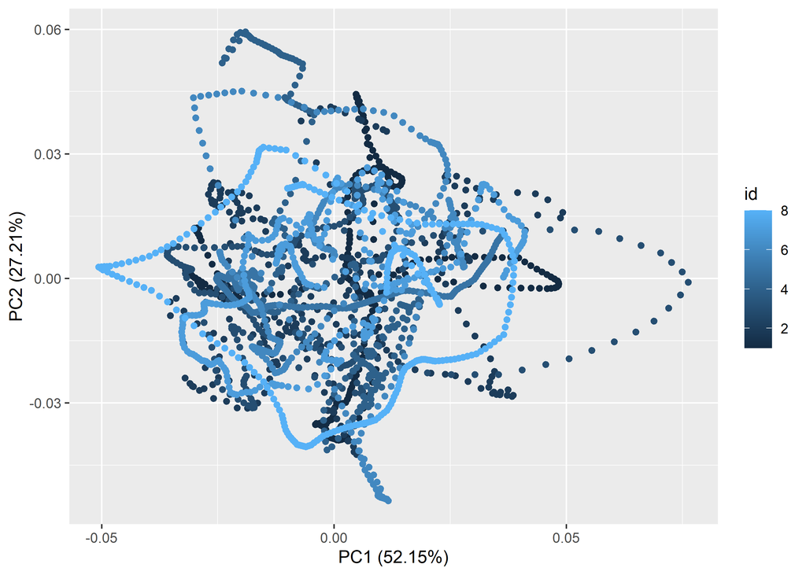

The plot shows that some gestures are close to each other as colors differ in every person’s gesture. Especially on the left-middle side of the plot, we can say that almost every gesture has a point on that area.